# Forest Fires NE Portugal

Shaurya Srivastava, Ishas Kekre, Anjali Viramgama

5/18/2020

CMSC320 Final Project

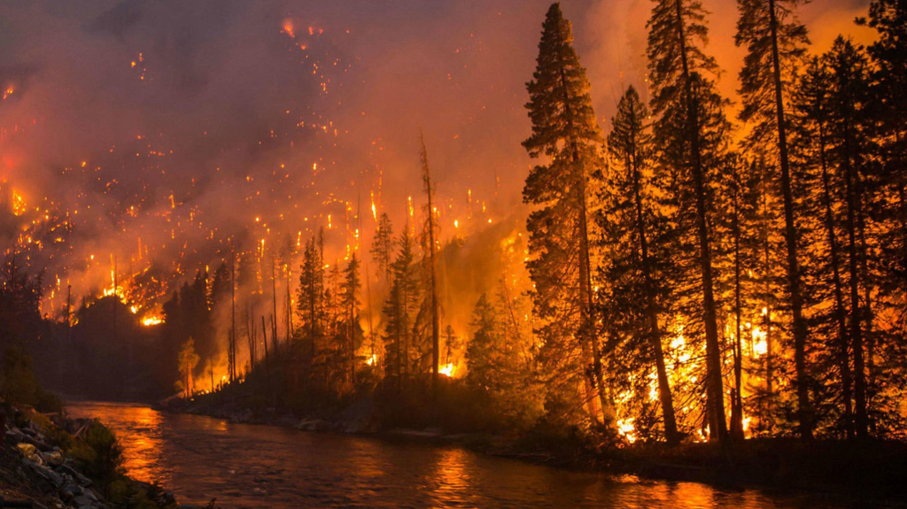

# 1 Introduction

Every year, there are many forest fires in regions all over the world. Recently, Australia had major fires, killing many different ecosystems and making some animals functionally extinct. Forest fires have the ablity to change the forest ecosystem vastly, for better or for worse. If we were able to predict forest fires and how much land they would burn, we can be better prepared. It would potentially be easier to control and people can take more precautions.

In this tutorial, we attempt to predict the burned area of forest fires, by using meteorological data in the Forest Fires Dataset provided by UCI’s Machine Learning Repository. We also perform other data analysis to learn more about forest fires in Northeast Portugal.

# 2 Dataset Used

The dataset used is from http://archive.ics.uci.edu/ml/datasets/Forest+Fires. It contains data about forest fires that have occurred at Northeast Portugal.

# 3 Dataset Information

Dataset characteristics: Multivariate  
Attribute characteristics: Real  
Number of Instances: 517  
Number of Attributes: 13  
Area: Physical

# 4 Understanding the Dataset

The dataset has the following attributes:  
1. X - x-axis spatial coordinate  
2. Y - y-axis spatial coordinate  
3. month - month of the year: ‘jan’ to ‘dec’  
4. day - day of the week: ‘mon’ to ‘sun’  
5. FFMC - FFMC index from the FWI system: 18.7 to 96.20  
6. DMC - DMC index from the FWI system: 1.1 to 291.3  
7. DC - DC index from the FWI system: 7.9 to 860.6  
8. ISI - ISI index from the FWI system: 0.0 to 56.10  
9. temp - temperature in Celsius degrees: 2.2 to 33.30  
10. RH - relative humidity in %: 15.0 to 100  
11. wind - wind speed in km/h: 0.40 to 9.40  
12. rain - outside rain in mm/m2 : 0.0 to 6.4  
13. area - the burned area of the forest (in ha): 0.00 to 1090.84  
(this output variable is very skewed towards 0.0, thus it may make sense to model with the logarithm transform).  
Here is what different components of the FWI system mean:  
FFMC- Fine Fuel Moisture Code, calculated using temperature, humidity, wind and rain.  
DMC - Duff Moisture Code, calculated using temperature, relative humidity and rain.  
DC - Drought Code, calculated using temperature and rain  
ISI - Initial Spread Index, calculated using wind.

# 5 Necessary Libraries for this Tutorial

These are the necessary libraries needed for reading and handling data, performing exploratory data analysis, hypothesis testing, and machine learning.

```r
library(dplyr)
library(tidyr)
library(lubridate)
library(tidyverse)
library(caret)
```

# 6 Data Preparation

## 6.1 Load the Dataset

```r
csv_file <- "forestfires.csv"
forest_fires <- read.csv(csv_file, stringsAsFactors = FALSE)
forest_fires %>% head()
```

```
##   X Y month day FFMC  DMC    DC  ISI temp RH wind rain area
## 1 7 5   mar fri 86.2 26.2  94.3  5.1  8.2 51  6.7  0.0    0
## 2 7 4   oct tue 90.6 35.4 669.1  6.7 18.0 33  0.9  0.0    0
## 3 7 4   oct sat 90.6 43.7 686.9  6.7 14.6 33  1.3  0.0    0
## 4 8 6   mar fri 91.7 33.3  77.5  9.0  8.3 97  4.0  0.2    0
## 5 8 6   mar sun 89.3 51.3 102.2  9.6 11.4 99  1.8  0.0    0
## 6 8 6   aug sun 92.3 85.3 488.0 14.7 22.2 29  5.4  0.0    0
```

## 6.2 Modify Dataset as Needed

Normally, this means dropping any columns that are unnecessary and adding columns that will be useful for further data analysis. We add a column with log of areas for better naalysis and convert all the months, which are from Jan to Dec to their respective numbers (1 to 12). We also add a season column (Fall, Spring, Summer and Winter) based on the months, which we will use for Hypothesis testing, and we divide the burn area level into two parts, big and small, depending on it’s log area.

### 6.2.1 Add a column with the log of the areas. Drop the day column. Convert the month abbreviations to numbers

```r
forest_fires_mod <- forest_fires %>%
  mutate(log_area = log(forest_fires$area + 1)) %>%
  select(-day)
forest_fires_mod$month <- sapply(forest_fires_mod$month,function(x) grep(paste("(?i)",x,sep=""),month.abb))
```

### 6.2.2 Add a column for the season

The season column is based on the month column.

```r
forest_fires_mod <- forest_fires_mod %>%
  mutate(season="winter")
forest_fires_mod$season[forest_fires_mod$month>2 & forest_fires_mod$month<6] <- "spring"
forest_fires_mod$season[forest_fires_mod$month>5 & forest_fires_mod$month<9] <- "summer"
forest_fires_mod$season[forest_fires_mod$month>8 & forest_fires_mod$month<12] <- "fall"
forest_fires_mod$season <- as.factor(forest_fires_mod$season)
```

### 6.2.3 Add a column for the burn area level

There are two burn area levels, small and large. Burn area has a small level when log(area) <= 2 and a large level when log(area) > 2.

```r
forest_fires_mod <- forest_fires_mod %>%
  mutate(burn_area_level="small")
forest_fires_mod$burn_area_level[forest_fires_mod$log_area>2] <- "large"
forest_fires_mod$burn_area_level <- as.factor(forest_fires_mod$burn_area_level)
```

### 6.2.4 Display the first few rows of the new modified dataframe.

```r
forest_fires_mod %>% head()
```

```
##   X Y month FFMC  DMC    DC  ISI temp RH wind rain area log_area season
## 1 7 5     3 86.2 26.2  94.3  5.1  8.2 51  6.7  0.0    0        0 spring
## 2 7 4    10 90.6 35.4 669.1  6.7 18.0 33  0.9  0.0    0        0   fall
## 3 7 4    10 90.6 43.7 686.9  6.7 14.6 33  1.3  0.0    0        0   fall
## 4 8 6     3 91.7 33.3  77.5  9.0  8.3 97  4.0  0.2    0        0 spring
## 5 8 6     3 89.3 51.3 102.2  9.6 11.4 99  1.8  0.0    0        0 spring
## 6 8 6     8 92.3 85.3 488.0 14.7 22.2 29  5.4  0.0    0        0 summer
##   burn_area_level
## 1           small
## 2           small
## 3           small
## 4           small
## 5           small
## 6           small
```

# 7 Exploratory Data Analysis

## 7.1 Histogram Showing Density of Forest Fires occurring over Months

We first try to find if there is any correlation between density of forest fires occurring over months.

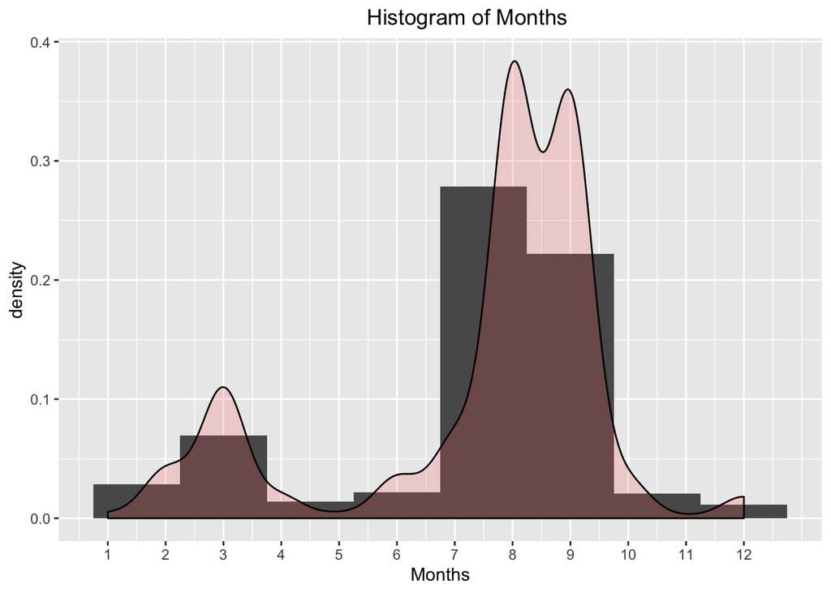

```r
forest_fires_mod %>%
  ggplot(mapping=aes(x=month),  breaks=100) +
    ggtitle("                                                   Histogram of Months") +
    geom_histogram(aes(y=..density..),binwidth=1.5) +
    geom_density(alpha=.2, fill="#FF6666") +
    scale_x_continuous(name ="Months",
                    breaks=seq(1,12,1))
```

There seems to be a higher density between months July to October, i.e. in summer and fall at Northeast Portugal.

## 7.2 Pie Chart Displaying the Percent of Total Fires per Season

To further confirm that forest fires occur more in the summer and fall, we plot a pie chat showing the percent of total fires per season.

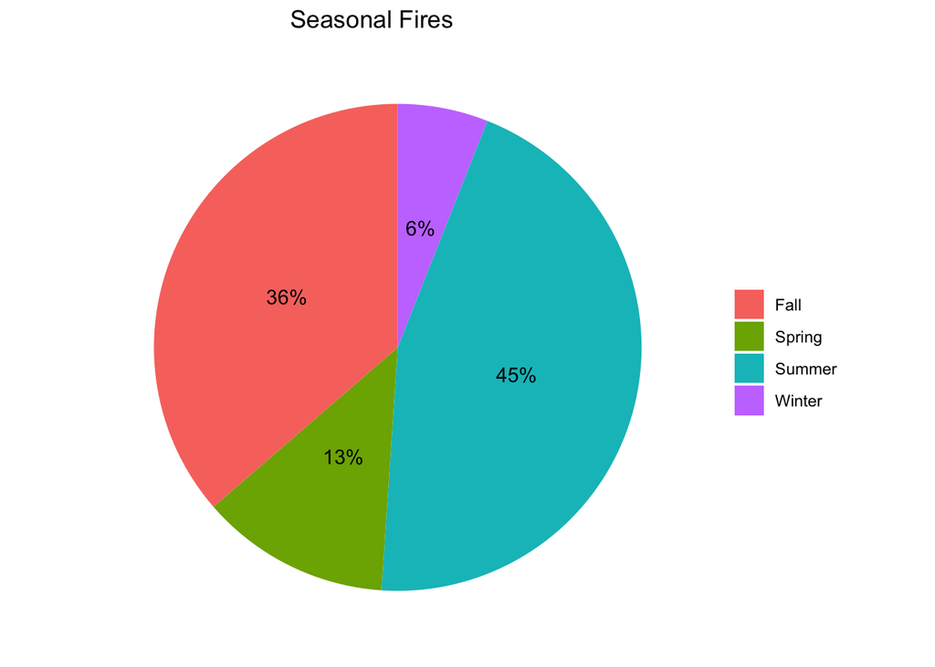

```r
t = nrow(forest_fires_mod)
s = nrow(forest_fires_mod %>% filter(season == 'summer'))
sp = nrow(forest_fires_mod %>% filter(season == 'spring'))
f = nrow(forest_fires_mod %>% filter(season == 'fall'))
w = nrow(forest_fires_mod %>% filter(season == 'winter'))
seasons <- data.frame(
  group = c("Summer", "Spring", "Fall", "Winter"),
  value = c(s/t, sp/t, f/t,w/t)
  )
seasons %>%
  ggplot(aes(x="", y=value, fill=group)) + geom_bar(stat="identity", width=1) +
  coord_polar("y", start=0) + geom_text(aes(label = paste0(round(value*100), "%")), position = position_stack(vjust = 0.5)) +
  labs(x = NULL, y = NULL, fill = NULL, title = "                             Seasonal Fires") +
  theme_classic() + theme(axis.line = element_blank(),
          axis.text = element_blank(),
          axis.ticks = element_blank())
```

This clearly shows that the tendency of a forest fire breaking out in Summer and Fall is higher than the other 2 seasons for Northeast Portugal.

## 7.3 Scatter Plot showing Log Burn Area vs Season

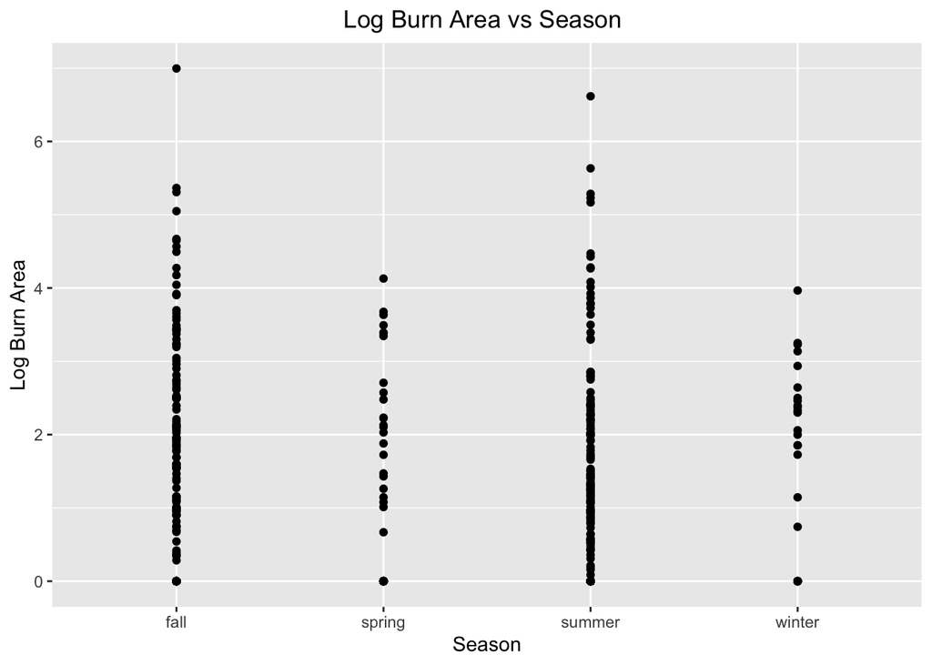

```r
forest_fires_mod %>%
  ggplot(aes(x=season,y=log_area)) +
    ggtitle("                                           Log Burn Area vs Season") +
    labs(x="Season", y="Log Burn Area") +
    geom_point()
```

This shows that summer and fall have high log burn areas that spring and winter. There is a very slight correlation with season and log burn area for Northeast Portugal.

## 7.4 Scatter Plots showing Burn Area Level vs the Different FWI Indices colored by Season

We know that the FWI indices are calculated using combinations of other indices and Tempurature, Wind Speed, Relative Humidity, and Rain. We would like to observe whether any of these indices have a correlation with the Burn Area Level grouped by Season.

### 7.4.1 Scatter plot for Burn Level vs FFMC colored by Season

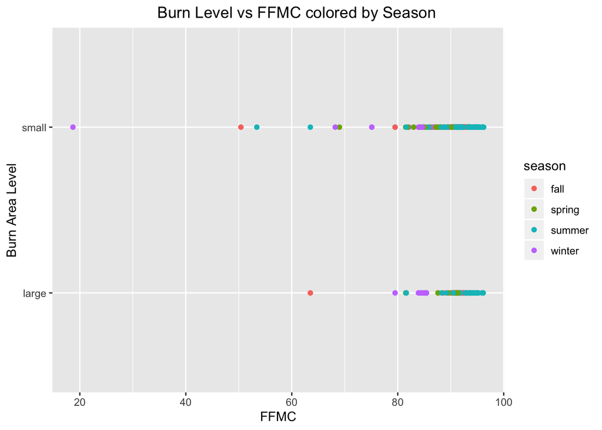

```r
forest_fires_mod %>%
  ggplot(aes(x=FFMC,y=burn_area_level, color = season)) +
    ggtitle("                        Burn Level vs FFMC colored by Season") +
    labs(x="FFMC", y="Burn Area Level") +
    geom_point()
```

From this plot, it is observed that low FFMC correlates with small burn area level. FFMC has a very slight correlation with burn area level. Grouping by season doesn’t change the correlation, so season is not an interaction for FFMC.

### 7.4.2 Scatter plot for Burn Level vs DMC colored by Season

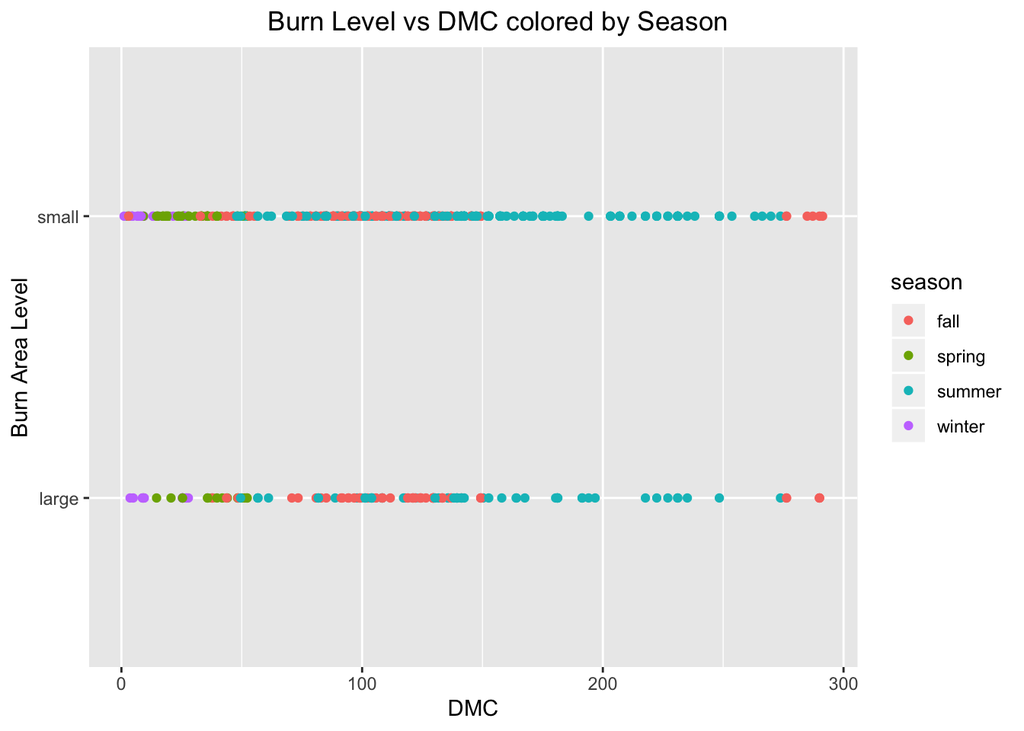

```r
forest_fires_mod %>%
  ggplot(aes(x=DMC,y=burn_area_level, color = season)) +
    ggtitle("                        Burn Level vs DMC colored by Season") +
    labs(x="DMC", y="Burn Area Level") +
    geom_point()
```

We observe that DMC grouped by season has no noticeable correlation with burn area level. Grouping by season doesn’t change the correlation, so season is not an interaction for DMC.

### 7.4.3 Scatter plot for Burn Level vs DC colored by Season

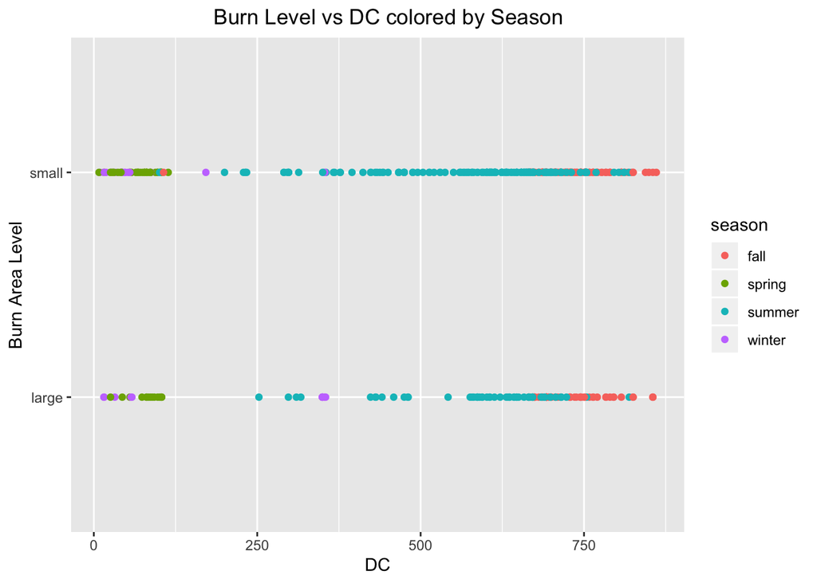

```r
forest_fires_mod %>%
  ggplot(aes(x=DC,y=burn_area_level, color = season)) +
    ggtitle("                        Burn Level vs DC colored by Season") +
    labs(x="DC", y="Burn Area Level") +
    geom_point()
```

We observe that DC grouped by season has no noticeable correlation with burn area level. Grouping by season doesn’t change the correlation, so season is not an interaction for DC.

### 7.4.4 Scatter plot for Burn Level vs ISI colored by Season

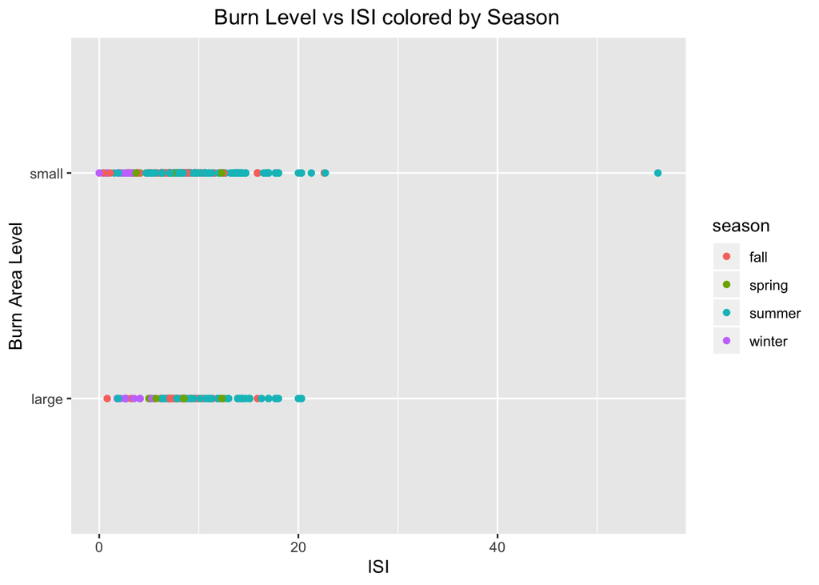

```r
forest_fires_mod %>%
  ggplot(aes(x=ISI,y=burn_area_level, color = season)) +
    ggtitle("                        Burn Level vs ISI colored by Season") +
    labs(x="ISI", y="Burn Area Level") +
    geom_point()
```

We observe that ISI grouped by season has no noticeable correlation with burn area level. Grouping by season doesn’t change the correlation, so season is not an interaction for ISI.

## 7.5 Areas of Forest Most Affected by Forest Fires

Just for fun, we plot another graph to show what areas of the forest are most affected by forest fires, in X and Y coordinates.

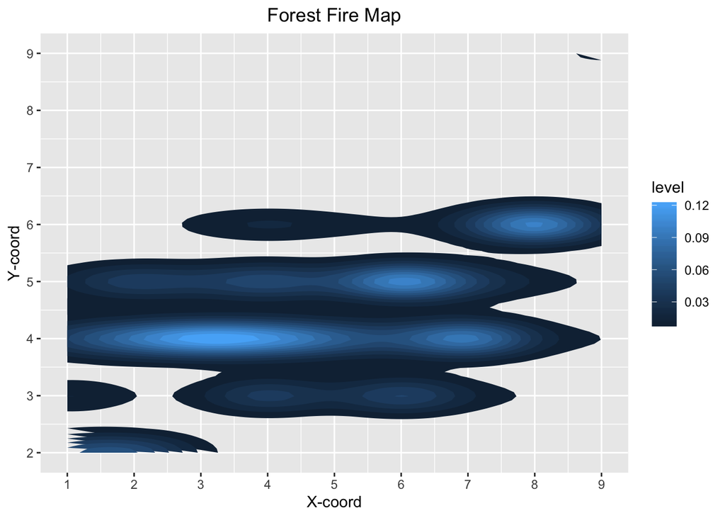

```r
forest_fires_mod %>%
  ggplot(aes(x=X, y=Y) ) +
  ggtitle("                                           Forest Fire Map") +
  stat_density_2d(aes(fill = ..level..), geom = "polygon") +
  scale_x_continuous(name ="X-coord",
                    breaks=seq(1,9,1)) +
  scale_y_continuous(name ="Y-coord",
                    breaks=seq(2,9,1))
```

# 8 Hypothesis Testing

## 8.1 First Hypothesis Test

For our first hypothesis test, we assumed that the probability of a forest fire occuring in every season is equal, i.e. it is 0.25 for summer, spring, winter and fall. We test it out for Fall specifically, assuming p = 0.25

### 8.1.1 H0: p = 0.25 Ha: p > 0.25 for fall

```r
fall_sample <- forest_fires_mod %>% filter(season == 'fall')
xbar = nrow(fall_sample)/nrow(forest_fires_mod)
u = 0.25
sigma = 0.25*(1-0.25)/nrow(forest_fires_mod)
z = (xbar-u)/(sqrt(sigma))
pval = pnorm(z, lower.tail=FALSE)
print(paste0("xbar: ", xbar), quote = FALSE)
```

```
## [1] xbar: 0.363636363636364
```

```r
print(paste0("mean: ", u), quote = FALSE)
```

```
## [1] mean: 0.25
```

```r
print(paste0("std: ", sqrt(sigma)), quote = FALSE)
```

```
## [1] std: 0.0190438768544635
```

```r
print(paste0("z-score: ", z), quote = FALSE)
```

```
## [1] z-score: 5.96708141439855
```

```r
print(paste0("p-value: ", pval), quote = FALSE)
```

```
## [1] p-value: 1.2076745434137e-09
```

Based on the results, we reject $H_o$. $pvalue = 1.208e-9 < \alpha = 0.05$, meaning that the probability is within rejection level $\alpha$. Therefore, there is enough evidence to reject $H_o$ and show that the true proportion of fires occuring in fall per year is greater than 0.25.

## 8.2 Second Hypothesis Test

For our second hypothesis test, we ran a test to see if the true mean temperature of forest fires in the area is 20 degrees. Since the sample mean was less than 20, we conducted a one-tailed lower t-test to see if the true mean could be 20.

### 8.2.1 H0: u = 20 Ha: u < 20 for temp

```r
xbar = mean(forest_fires_mod$temp)
u = 20
s = sd(forest_fires_mod$RH)
n = nrow(forest_fires_mod)
t = (xbar-u)/(s/sqrt(n))
pval = pt(t, df=n-1)
print(paste0("xbar: ", xbar), quote = FALSE)
```

```
## [1] xbar: 18.88916827853
```

```r
print(paste0("mean: ", u), quote = FALSE)
```

```
## [1] mean: 20
```

```r
print(paste0("std: ", s/sqrt(n)), quote = FALSE)
```

```
## [1] std: 0.717641476597067
```

```r
print(paste0("t-score: ", t), quote = FALSE)
```

```
## [1] t-score: -1.54789230792149
```

```r
print(paste0("p-value: ", pval), quote = FALSE)
```

```
## [1] p-value: 0.0611306502867482
```

## 8.3 Third Hypothesis Test

For our third hypothesis test, we ran a test to see if the true mean area of forest fires in the area is 20 hectare units. For this test we are showing how to conduct a two-tailed t-test to see if the true mean could be 20.

### 8.3.1 H0: u = 20 Ha: u != 20 for area

```r
xbar = mean(forest_fires_mod$area)
u = 20
s = sd(forest_fires_mod$area)
n = nrow(forest_fires_mod)
t = (xbar-u)/(s/sqrt(n))
pval = 2*pt(t, df=n-1)
print(paste0("xbar: ", xbar), quote = FALSE)
```

```
## [1] xbar: 12.8472920696325
```

```r
print(paste0("mean: ", u), quote = FALSE)
```

```
## [1] mean: 20
```

```r
print(paste0("std: ", s/sqrt(n)), quote = FALSE)
```

```
## [1] std: 2.79957969518245
```

```r
print(paste0("t-score: ", t), quote = FALSE)
```

```
## [1] t-score: -2.55492206300681
```

```r
print(paste0("p-value: ", pval), quote = FALSE)
```

```
## [1] p-value: 0.0109069999563108
```

# 9 Machine Learning

Based on the attributes of the dataset, we know that the different FWI Indices provide different information of Forest Fires, and when combined, they tell fire intensity. There is no noticeable or strong correlation with any of the indices and burn area level. However, as the indices are used to calculate the fire intensity, we try to see if using these indices can predict burn area level.

## 9.1 What are we trying to predict

Will a forest fire burn area level be large or small?

## 9.2 Prepare the data set for the machine learning prediction task

Drop all the columns except for the FWI Indices, Season, and the Burn Area Level.

```r
forest_learning <- forest_fires_mod %>% select(-month,-X,-Y,-area,-log_area,-rain,-temp,-RH,-wind)
forest_learning %>% head()
```

```
##   FFMC  DMC    DC  ISI season burn_area_level
## 1 86.2 26.2  94.3  5.1 spring           small
## 2 90.6 35.4 669.1  6.7   fall           small
## 3 90.6 43.7 686.9  6.7   fall           small
## 4 91.7 33.3  77.5  9.0 spring           small
## 5 89.3 51.3 102.2  9.6 spring           small
## 6 92.3 85.3 488.0 14.7 summer           small
```

## 9.3 Prediction Algorithm

This code will set up the cross validation experiment with knn algorithm from the Caret Library. It utilizes repeatedcv, creating 5 folds and repeating the experiment 5 times. The experiment provides ROC values and a method to calculate the AUROC values.

```r
set.seed(1234, sample.kind = "Rounding")

# create the cross-validation partition
cv_partition <- createFolds(forest_learning$burn_area_level,k=5)

# setup training parameters
fit_control <- trainControl(
  method = "repeatedcv",
  number = 5,
  repeats = 5,
  #indexOut = cv_partition,
  summaryFunction=twoClassSummary,
  classProbs=TRUE,
  savePredictions=TRUE)

# a function to obtain performance data
# (tpr and fpr) over the given cross validation
# partitions, for the number of trees in the
# random forest
get_roc_data <- function(cv_partition, final_df) {
  mean_fpr <- seq(0, 1, len=100)
  aucs <- numeric(length(cv_partition))

  # iterate over folds
  res <- lapply(seq_along(cv_partition),  function(i) {
    # train the random forest
    fit <- train(burn_area_level~.,
                        data = final_df[-cv_partition[[i]],], # all but the holdout set
                        method = "knn",
                        trControl = fit_control,
                        preProcess = c("center","scale"),
                        tuneLength = 20,
                        metric="ROC")

    # make predictions on the holdout set
    preds <- predict(fit, newdata=final_df[cv_partition[[i]],],type="prob")$large

    # compute tpr and fpr from the hold out set
    perf <- ROCR::prediction(preds, final_df$burn_area_level[cv_partition[[i]]]) %>%
      ROCR::performance(measure="tpr", x.measure="fpr")

    fpr <- unlist(perf@x.values)
    tpr <- unlist(perf@y.values)

    # interpolate the roc curve over 0, 1 range
    interp_tpr <- approxfun(fpr, tpr)(mean_fpr)
    interp_tpr[1] <- 0.0

    # collect values for this fold
    data_frame(fold=rep(i, length(mean_fpr)), fpr=mean_fpr, tpr=interp_tpr)
  })

  # combine values across all folds
  # into a single data frame
  do.call(rbind, res)
}

# calculate area under the ROC curve
# from tpr and fpr values across folds
compute_auc <- function(curve_df) {
  curve_df %>%
    group_by(fold) %>%
    summarize(auc=pracma::trapz(fpr, tpr))
}
```

## 9.4 Execute the prediction

We will get performance data from using our machine learning algorithm.

```r
curve_df <- get_roc_data(cv_partition,forest_learning)
auc_df <- compute_auc(curve_df)
```

## 9.5 Plot AUROC

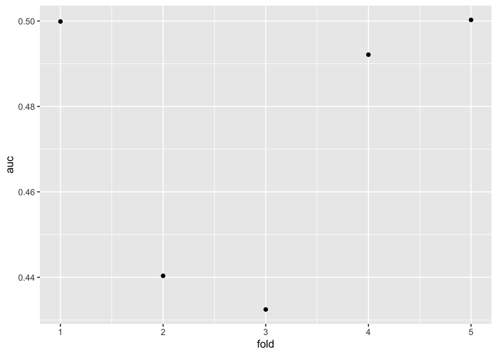

```r
ggplot(auc_df, aes(x=fold, y=auc)) +
  geom_point()
```

This tells us the area under the ROC curve for each fold. The AUROC values are on the lower end for each fold, mostly less than 0.5. The low values convey that the model used isn’t good for the prediction of the Burn Area Level.

## 9.6 Plot ROC Curve

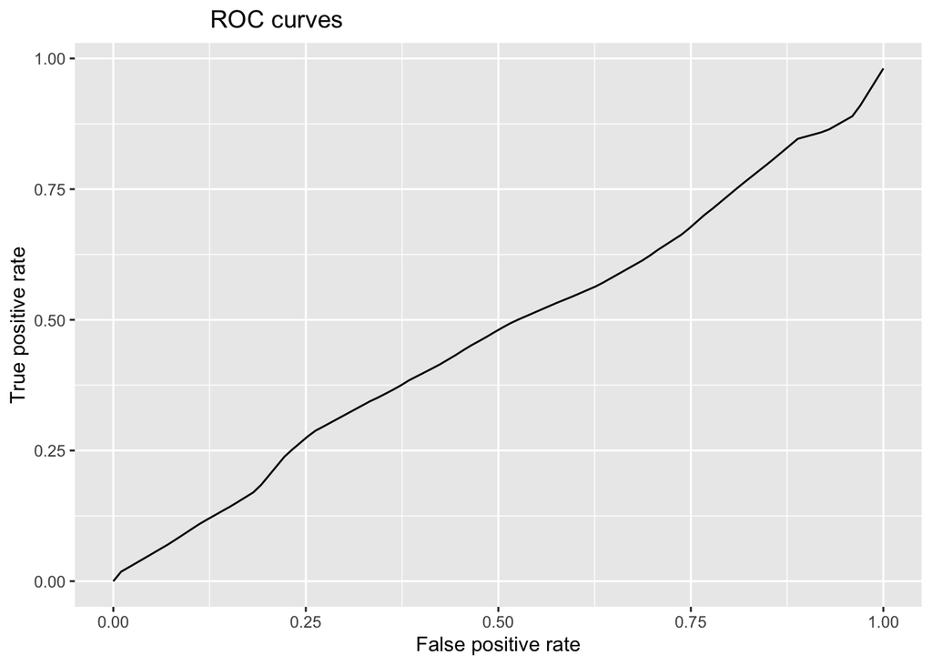

```r
curve_df %>%
  group_by(fpr) %>%
  summarize(tpr = mean(tpr)) %>%
  ggplot(aes(x=fpr, y=tpr)) +
    geom_line() +
    labs(title = "                    ROC curves",
         x = "False positive rate",
         y = "True positive rate")
```

## 9.7 Machine Learning Conclusion

The ROC Model is a straight line, meaning that this model/algorithm is not good for predicting the Burn Area Level.

## 9.8 Tutorial Conclusion

In this tutorial, we went over how to perform data analysis on the Forest Fires Northeast Portugal dataset, provided by the UCI database. We performed Exploratory Data Analysis, Hypothesis Testing, and Machine Learning. These are all important tools of analysis to get a better understanding of the data.

From the Hypothesis Testing, we showed different techniques to perform hypothesis tests on samples of data. We showed how to come up with null and alternate hypothesis, conduct tests on the sample data, and how to understand and analyse those tests. In real life samples, there are a lot of unknowns, and these hypothesis tests are important in understanding data and making assumptions about your data.

From the Machine Learning, we learn that our model isn’t good at predicting the Burn Area Level. In fact, with further analysis of the data, we realize that possibly no traditional machine learning algorithm can accurately predict Burn Area Level. We should look into Neural Networks or other machine learning algorithms. We could probably use this dataset and traditional machine learning algorithms to predict another attribute other than Burn Area Level, such as what season did a forest fire occur based on the FWI Indices and other meteorological data.

# 10 References

Dataset - [Cortez and Morais, 2007] P. Cortez and A. Morais. A Data Mining Approach to Predict Forest Fires using Meteorological Data. In J. Neves, M. F. Santos and J. Machado Eds., New Trends in Artificial Intelligence, Proceedings of the 13th EPIA 2007 - Portuguese Conference on Artificial Intelligence, December, Guimarães, Portugal, pp. 512-523, 2007. APPIA, ISBN-13 978-989-95618-0-9. Available at: [http://archive.ics.uci.edu/ml/datasets/Forest+Fires]

To Learn Additional Data Science Concepts - https://www.hcbravo.org/IntroDataSci/bookdown-notes/

Tutorial on ggplot by r-statistics.co - http://r-statistics.co/Complete-Ggplot2-Tutorial-Part1-With-R-Code.html

Machine Learning using caret - http://www.rebeccabarter.com/blog/2017-11-17-caret_tutorial/

Forest Fire Image - https://e360.yale.edu/assets/site/_1500x1500_fit_center-center_80/Washington-DNR-Chiwaukum-WildFires-2014-2015_WA-DNR_cropped.jpg